# Week 4: Experiments - Covariate Adjustment

PS 813 - Causal Inference

Anton Strezhnev

strezhnev@wisc.edu

University of Wisconsin-Madison

February 8, 2027

$$\require{cancel}
\DeclareMathOperator*{\argmin}{arg\,min}$$

$$\DeclareMathOperator*{\argmax}{arg\,max}$$

## Where we’ve been

- **Causal effects** as contrasts in **potential outcomes**
  - **Average** causal effects as estimands that we can **identify** under assumptions on the experimental design
- **Randomized experiments** identify **average treatment effects**
  - Observed treated (control) groups are **representative** of what would happen **on average** if whole sample received treatment (control)
- Conditioning on **post-treatment** covariates breaks your experiment
  - Endogenous selection bias - treated group no longer comparable to the controls
  - **For non-compliance** - we’ll learn how to identify the **Complier Average Causal Effect**
- External validity is a question of **effect heterogeneity**

## Some thoughts on identification assumptions

- (Nearly) every causal identification assumption can be thought of as a variation on these **three ideas**
- **Randomization** - Something is statistically **independent** of something else
  - (e.g.) Ignorability of **treatment** for a conventional randomized experiment
- **Effect homogeneity** - We know something about the *individual* treatment effects
  - (e.g.) Monotonicity - effects are only in *one* direction.
- **Correct model** - We know the true model for something (e.g. outcome $Y$)
  - Hard to credibly justify in most social science setting, but underpins a lot of “pre-credibility revolution” empirical work even if not explicit.

## This week

- What if we want more **precision** in our experiments
  - We can increase the sample size…but that’s expensive!
  - For a **given** sample size, can we do better than complete randomization?
- **Covariate adjustment** eliminates variability in $Y$ driven by **non-treatment** characteristics
  - Adjustment **ex-ante** via stratification/blocking
  - Adjustment **ex-post** via post-stratification
- Linear regression in its **agnostic** form.
  - OLS as an estimator of the **Best Linear Predictor**
  - Can we get the model wrong for $E[Y | X]$ and still get consistent estimates of treatment effects? **Yes!**

## Stratification

## Power and Precision

- In a conventional hypothesis test, we control the **Type I** error - the **false positive rate**
  - **Given** that the null is true, what’s the probability that we reject it?
  - We **choose** this number (e.g.) $\alpha = .05$
- But we also want to know the **Type II** error - the **false negative rate**
  - **Given** that the null is **false**, what’s the probability that we **fail** to reject it?
- The **false negative rate** in our typical hypothesis test depends on:
  - **The true effect size**
  - **The sampling variance of the estimator**
- For the Neyman variance, what makes it **smaller**?

  $$Var(\hat{\tau}) = \frac{S^2_t}{N_t} + \frac{S^2_c}{N_c}$$

## Covariate adjustment

- How do we reduce the outcome variance?
  - Often we’ll **transform** the outcome (e.g. differencing using a pre-treatment measure of that outcome)
- But our most useful technique is to find factors that **predict** the outcome and **eliminate** the variance attributable to those factors.
- Recall from the **law of total variance**

  $$Var(Y) = \underbrace{\mathbb{E}[Var(Y | X)]}_{\text{unexplained by } X} + \underbrace{Var(\mathbb{E}[Y|X])}_{\text{explained by } X}$$
- Adjusting for covariates $X$ in an experiment **eliminates** variance in $Y$ that is attributable to $X$

## Stratification/Blocking

- It is common to build the covariate adjustment directly into the experimental design through **blocking** or **stratification**
- Before assigning treatment, partition the sample that puts the $N$ units into $G$ mutually-exclusive strata
  - With discrete covariates, each bin $g$ is a unique combination of the covariates
  - With continuous covariates, we can coarsen into discrete bins (e.g. age $\to$ “25-40”)
  - Each stratum $g$ has $N_g$ units.
- Within **each stratum** treatment is completely randomized
  - $N_{t, g}$ units receive treatment
  - $N_{c, g} = N_g - N_{t, g}$ units receive control.

## Quiz

- If $N_{t, g}/N_g$ is the same across all strata, can I analyze the experiment like I would with complete randomization?
- How about if $N_{t,g}/N_g$ *varies* between strata?

## Estimation

- Our estimator is the **stratified** difference-in-means
- We start by estimating each **stratum-specific** treatment effect $\tau_g$ using the difference-in-means in that stratum

  $$\hat{\tau_g} = \frac{1}{N_{t,g}}\sum_{i: G_i = g}^N Y_i D_i - \frac{1}{N_{c,g}}\sum_{i: G_i = g}^N Y_i (1 - D_i)$$
- And we can estimate the sampling variance using the within-stratum Neyman variance estimator

  $$\widehat{Var(\hat{\tau_g})} = \frac{s_{t,g}^2}{N_{t,g}} + \frac{s_{c,g}^2}{N_{c,g}}$$
- $s_{t,g}^2$, $s_{c,g}^2$ are the sample variance of $Y$ within the treated group and control group respectively in stratum $g$.
- **Imagine:** We ran $G$ independent mini-experiments and analyzed them separately. Each is unbiased for the conditional ATE (CATE) and has its own standard error.
  - But we care about the **average treatment effect**

## Estimation under block-randomization

- How do we aggregate to get an estimate of the ATE? Take a weighted average by stratum size

  $$\hat{\tau} = \sum_{g = 1}^G \hat{\tau_g} \times \frac{N_g}{N}$$
- And the sampling variance?

  $$\widehat{Var_{\text{strat}}(\hat{\tau})} = \sum_{g = 1}^G \widehat{Var(\hat{\tau_g})} \times \left(\frac{N_g}{N}\right)^2$$
- When is the variance of the blocked design going to be lower than the variance under complete randomization?
  - When the strata **explain some of the variance** in $Y$ (the population $S^2_{t,g} < S^2_{t}$ and $S^2_{c,g} < S^2_{c}$ )

## Post-stratification

- Suppose we didn’t stratify ex-ante but have some covariates that we observe? Can we analyze *as-though* we had stratified on these?
  - Yes: **Post-stratification**
- Key difference from stratification: Number of treated/control w/in stratum is random and not fixed. Stratum sizes also not fixed.
  - Not as efficient as if we had blocked ex-ante!
- **Miratrix, Sekhon and Yu (2013)**
  - Usually not a problem - relative to blocking ex-ante, the differences in variances are small.
  - Problems with many strata + poorly predictive strata.
  - Unlike the Athey and Imbens setting, benefits not guaranteed, but often doesn’t hurt with good covariate choice.

## Example: Nyhan and Reifler (2015)

- **Nyhan and Reifler (2015)** conduct a field experiment on state legislators in November 2012 to study whether politicians reacted to external monitoring of their statements.
  - **Treatment** - Legislators received a letter warning them of the risks of having false statements exposed by fact-checkers
  - **Placebo** - Legislators received a letter warning that their statements would be observed.
  - **Control** - No mailer
- Treatment was **block-randomized**
  - **Exact blocking** on state, political party, legislative chamber and existence of a previous PolitiFact rating
  - Coarsened matching on previous vote share and fundraising
- **Outcome**:
  - Did the legislator receive a negative PolitiFact rating?
  - Was there media coverage of a legislator’s inaccurate statements?

## Example: Nyhan and Reifler (2015)

- For the main analysis, the paper combines the Placebo/Control conditions.

```r
factcheck <- haven::read_dta("assets/data/nyhan-reifler-fe.dta")
table(factcheck$treatment)
```

```
  0   1
777 392
```

- Let’s check balance
  - We know balance is exact on state/party/chamber and whether there is a past fact check.
  - Coarse balance on fundraising and vote share
  - Other covariates observed but not explicitly “blocked” on (e.g. leadership position)

## Example: Nyhan and Reifler (2015)

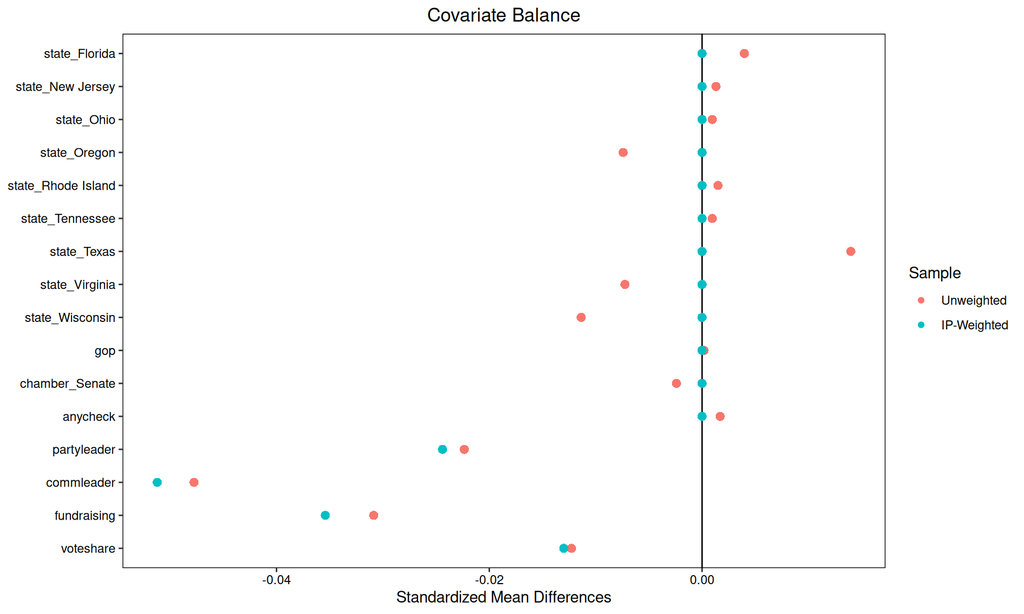

## Example: Nyhan and Reifler (2015)

- The **original paper** estimates the treatment effect on each of the three outcomes using a **weighted** difference-in-means.
  - The weights are negligible but address the slight non-uniformity in treatment assignment across randomization strata.
- Here, we replicate the original estimate for the **combined** “any PolitiFact check or LexisNexis news article questioning accuracy” outcome

```r
dm_est <- tidy(lm_robust(combined ~ treatment, data=factcheck, weights=aw))
dm_est %>% filter(term == "treatment") %>% select(estimate, std.error, statistic, p.value)
```

```
     estimate   std.error statistic    p.value
1 -0.01568843 0.008225802 -1.907223 0.05673708
```

- But this is kind of a waste of blocking.
  - Why do the blocking if you’re not going to incorporate it into the analysis?!
  - Again, the point of blocking in an experiment is not bias reduction but variance reduction!
  - This paper uses a **too conservative** variance estimator.

## Example: Nyhan and Reifler (2015)

- The paper *does* include the randomization strata. Unfortunately **many** of those strata have only a single treated observation.
  - Why is this a problem? We can’t estimate the **stratum-specific variance** with a single observation!
- **Advice**: If you’re stratifying, make sure to have **at least two** or so observations per condition per stratum
  - Otherwise, if you are pair-randomizing, just take the **within-pair differences** and use a conventional sample mean estimator.
- Let’s take a look at the strata and see what covariate levels they capture - maybe we can combine some?

```r
block_summaries <- factcheck %>% group_by(blockdummy) %>% summarize(state = state[1],
                                                                    chamber = chamber[1],
                                                                    gop = mean(gop),
                                                                    anycheck = mean(anycheck),
                                                                    N_Treated = sum(treatment),
                                                                    N_Control = sum(treatment == 0))
```

## Example: Nyhan and Reifler (2015)

|  | blockdummy | state | chamber | gop | anycheck | N_Treated | N_Control |
| --- | --- | --- | --- | --- | --- | --- | --- |
| 1 | 1 | Florida | House | 0 | 0 | 10 | 20 |
| 2 | 2 | Florida | House | 0 | 1 | 3 | 5 |
| 3 | 3 | Florida | House | 1 | 0 | 21 | 42 |
| 4 | 4 | Florida | House | 1 | 1 | 6 | 12 |
| 5 | 5 | Florida | Senate | 0 | 0 | 3 | 5 |
| 6 | 6 | Florida | Senate | 0 | 1 | 1 | 2 |
| 7 | 7 | Florida | Senate | 1 | 0 | 3 | 6 |
| 8 | 8 | Florida | Senate | 1 | 1 | 6 | 12 |
| 9 | 9 | New Jersey | House | 0 | 0 | 12 | 24 |
| 10 | 10 | New Jersey | House | 0 | 1 | 4 | 7 |

[output cut: 59 more lines]

## Example: Nyhan and Reifler (2015)

- Basically a lot of strata have too few members within a party who are previously fact checked (fact checks are rare). We’ll combine some of these strata for the analysis.
  - Could go through and manually merged - to save time, I’ll just ignore chamber (it’s not that prognostic)
- Let’s make those strata (`paste()` just concatenates the raw variable values)

```r
factcheck <- factcheck %>% mutate(groupedblocks = paste(state, gop, anycheck, sep="-"))
factcheck$groupedblocks[factcheck$groupedblocks == "Virginia-1-1"] <- "Virginia-0-1" # Merge some Virginia strata that still have too few units
```

- Now, we can calculate the **stratified** difference-in-means estimate and compute the correct sampling variance!
  - You can do this with `group_by` and `mean()` and `var()` (or for this case, `weighted.mean()` and `weighted.var()`)
  - But it’s **so much easier** to do this with a (special) regression.
  - We’ll explain why this works later, but for now, let’s show you the estimate!

## Example: Nyhan and Reifler (2015)

- We use the **Lin (2013)** estimator in the `estimatr` package
  - Mathematically equivalent to our stratified difference-in-means estimator when using dummy indicators for strata (we’ll show you why later)

```r
stratified_est <- tidy(estimatr::lm_lin(combined ~ treatment, covariates = ~ groupedblocks, data=factcheck, weights=aw))
stratified_est %>% filter(term == "treatment") %>% select(estimate, std.error, statistic, p.value)
```

```
     estimate   std.error statistic p.value
1 -0.01568843 0.008138779 -1.927615 0.05416
```

- Compare with the case where we use the **conservative** variance estimator that ignores the strata

```r
dm_est %>% filter(term == "treatment") %>% select(estimate, std.error, statistic, p.value)
```

```
     estimate   std.error statistic    p.value
1 -0.01568843 0.008225802 -1.907223 0.05673708
```

## Summary

- **Stratification/Blocking** is a tool for reducing the **variance** of your treatment effect estimator
  - **Ex-ante** - Doesn’t hurt
  - **Ex-post** - Usually doesn’t hurt if the covariates are predictive enough.
- Take care to use an **estimator** that actually leverages the variance-reduction
  - A **stratified** difference-in-means
  - Equivalent to OLS with de-meaned dummies for the strata interacted with the treatment indicator (the **“Lin”** estimator)
- What to block on?
  - Things that **predict** the outcome
  - Surprisingly hard to find good ones! Best ones tend to be prior measures of the outcome.

## Linear Regression

## Linear Regression

- We often want to adjust for **additional** covariates when trying to estimate a treatment effect
  - In an RCT - **prognostic** covariates that reduce variance in Y
  - (**Next week**) - In an observational design - both **prognostic** covariates and **confounders** of Y and X
- By the law of total expectation, we can write the ATE as an **expectation** over the distribution of CATEs

  $$\tau = \mathbb{E}_X\bigg[\mathbb{E}[Y_i(1) | X_i] - \mathbb{E}[Y_i(0) | X_i]\bigg]$$
- Under our consistency + ignorability assumptions:

  $$E[Y_i(1) | X_i] = E[Y_i | D_i = 1, X_i]$$
- Now we have a **statistical** problem, estimating the CEF of $Y_i$ given $X_i$ and $D_i$
  - This is the task of **regression**
  - A ubiquitous regression **estimator** is **ordinary least squares**

## Set-up

- We’ll denote our vector of $N$ observed outcomes with $Y$
- We observe $K$ predictors for each unit $i$ collected in a matrix $\mathbf{X}$
  - Each **row** is a $K$-length vector $X_i$ denoting the covariates observed for unit $i$

  $$\mathbf{X} = \begin{pmatrix} X_1^\prime \\ X_2^\prime \\ \vdots \\ X_N^\prime \end{pmatrix}_{N \times K} \qquad Y = \begin{pmatrix} Y_1 \\ Y_2 \\ \vdots \\ Y_N \end{pmatrix}_{N \times 1}$$
- We’ll use the $\prime$ notation to denote the transpose of a matrix and treat vectors by default as **column** vectors (so $X_i^\prime$ is a $1 \times K$ row-vector)
- We assume an $i.i.d.$ random sample from the target population of interest (though can relax this!)

## Best Linear Predictor (BLP)

- The **Best Linear Predictor** or **population regression** is a function of some input vector $x$ of length $K$

  $$m(x_i) = x^\prime\beta = \beta_0 + \beta_1 x_1 + \beta_2 x_2 + \beta_3 x_3 + \dotsc + \beta_K x_K$$
- The $\beta$ parameters minimize the **expected prediction error**

  $$\beta = \argmin_b \ \mathbb{E}[(Y_i - X_i^\prime b)^2]$$
- Note that this is a **population** quantity
  - $m(x)$ is an **estimand** like any other estimand we’ve talked about
  - $m(x)$ and $E[Y|X]$ might differ substantially!

## Best Linear Predictor (BLP)

- Is there a closed form expression for the population regression coefficients $\beta$?
  - Yes - with some algebra (solving the optimization problem), we get

  $$\beta = (\mathbb{E}[X_iX_i^\prime])^{-1}\mathbb{E}[X_iY_i]$$
- Recall from intro that in the **bivariate** case, that the expression for the slope coefficient $\beta_1$ can be written as:

  $$\beta_1 = \frac{Cov(X_i, Y_i)}{Var(X_i)}$$
- What have we assumed so far?
  - Finite mean/variance/covariances for $Y$ and $X$
  - $\mathbb{E}[X_iX_i^\prime]$ is invertible (no perfect collinearity in columns of $X$)

## Projection error

- What can we say about the difference between the BLP and $Y$?

  $$e_i = Y_i - m(X_i)$$
- Rewriting, we have

  $$Y_i = X_i^\prime\beta + e_i$$
- $e_i$ is the **projection error** since the BLP is the “best” **projection** of $Y$ into the space of linear combinations of the columns of $\mathbf{X}$

## Projection error

- We can show that the projection error is mechanically uncorrelated with the predictors

$$\begin{align*}
\mathbb{E}[X_i e_i] &= \mathbb{E}[X_i(Y_i - X_i^\prime\beta)]\\
&= \mathbb{E}[X_iY_i] - \mathbb{E}[X_iX_i^\prime]\beta\\
&= \mathbb{E}[X_iY_i] - \mathbb{E}[X_iX_i^\prime](\mathbb{E}[X_iX_i^\prime])^{-1}\mathbb{E}[X_iY_i]\\
&= \mathbb{E}[X_iY_i] - \mathbb{E}[X_iY_i] = 0\\
\end{align*}$$

- Since $X_{ik} = 1$ is typically one of the regressors (the “intercept”), this also implies $\mathbb{E}[e_i] = 0$

## Projection error

- This means that the covariance of $X_i$ and the projection error $e_i$ is zero!

$$\begin{align*}
Cov(X_i, \epsilon) = \mathbb{E}[X_ie_i] - E[X_i]E[e_i] = 0 - 0 = 0
\end{align*}$$

- Importantly, we have derived these properties on the **Best Linear Predictor** and the **projection error** without making any assumptions on the error itself!
  - This is **mechanically true** by the way we’ve defined the BLP

## Estimating the BLP

- Remember, $m(X)$ is a *population quantity* - can we come up with an *estimator* in our sample that is consistent for it?
  - **plug-in principle** - Where we have population expectations, plug in their sample equivalents
- Our estimand

  $$\beta = (\mathbb{E}[X_iX_i^\prime])^{-1}\mathbb{E}[X_iY_i]$$
- Our estimator

  $$\hat{\beta} = \bigg(\frac{1}{N} \sum_{i=1}^N X_iX_i^\prime\bigg)^{-1}\bigg(\frac{1}{N} \sum_{i=1}^N X_iY_i\bigg)$$
- Often written as:

  $$\hat{\beta} = (\mathbf{X}^\prime\mathbf{X})^{-1}(\mathbf{X}^\prime Y)$$

## Estimating the BLP

- To visualize how $\mathbf{X}^\prime\mathbf{X}$ is a sum over the **outer products** $X_{i}X_{i}^\prime$

$$\mathbf{X}^\prime \mathbf{X} = \begin{pmatrix} x_{11} & x_{21} & x_{31} & \cdots & x_{N1} \\ x_{12} & x_{22} & x_{32} & \cdots & x_{N2} \\ \vdots & \vdots & \vdots & \ddots & \vdots \\ x_{1K} & x_{2K} & x_{3K} & \cdots & x_{NK} \end{pmatrix}_{K \times N} \begin{pmatrix} x_{11} & x_{12} & \cdots & x_{1K} \\ x_{21} & x_{22} & \cdots & x_{2K} \\ x_{31} & x_{32} & \cdots & x_{3K} \\ \vdots & \vdots & \ddots & \vdots \\ x_{N1} & x_{N2} & \cdots & x_{NK} \end{pmatrix}_{N \times K}$$

$$= \underbrace{\begin{pmatrix} x_{11}^2 & x_{11}x_{12} & \cdots & x_{11}x_{1K} \\ x_{12}x_{11} & x_{12}^2 & \cdots & x_{12}x_{1K} \\ \vdots & \vdots & \ddots & \vdots \\ x_{1K}x_{11} & x_{1K}x_{12} & \cdots & x_{1K}^2 \end{pmatrix}}_{X_1 X_1^\prime} + \cdots + \underbrace{\begin{pmatrix} x_{N1}^2 & x_{N1}x_{N2} & \cdots & x_{N1}x_{NK} \\ x_{N2}x_{N1} & x_{N2}^2 & \cdots & x_{N2}x_{NK} \\ \vdots & \vdots & \ddots & \vdots \\ x_{NK}x_{N1} & x_{NK}x_{N2} & \cdots & x_{NK}^2 \end{pmatrix}}_{X_N X_N^\prime}$$

## Estimating the BLP

- And likewise for $\mathbf{X}^\prime Y$

$$\mathbf{X}^\prime Y = \begin{pmatrix} x_{11} & x_{21} & x_{31} & \cdots & x_{N1} \\ x_{12} & x_{22} & x_{32} & \cdots & x_{N2} \\ \vdots & \vdots & \vdots & \ddots & \vdots \\ x_{1K} & x_{2K} & x_{3K} & \cdots & x_{NK} \end{pmatrix}_{K \times N} \begin{pmatrix} Y_1 \\ Y_2 \\ Y_3 \\ \vdots \\ Y_N \end{pmatrix}_{N \times 1} = \begin{pmatrix} x_{11}Y_1 + x_{21}Y_2 + x_{31}Y_3 + \cdots + x_{N1}Y_N \\ x_{12}Y_1 + x_{22}Y_2 + x_{32}Y_3 + \cdots + x_{N2}Y_N \\ \vdots \\ x_{1K}Y_1 + x_{2K}Y_2 + x_{3K}Y_3 + \cdots + x_{NK}Y_N \end{pmatrix}_{K \times 1}$$

## Estimating the BLP

- Is $\hat{\beta}$ consistent for $\beta$?
- Let’s write $\hat{\beta}$ as a function of $\beta$ and the **projection error**

  $$\hat{\beta} = \beta + \bigg(\frac{1}{n} \sum_{i=1}^n X_iX_i^\prime\bigg)^{-1}\bigg(\frac{1}{n} \sum_{i=1}^n X_ie_i\bigg)$$
- We can use the **weak law of large numbers**

  $$\frac{1}{N} \sum_{i=1}^N X_iX_i^\prime \overset{p}{\to} \mathbb{E}[X_iX_i^\prime]$$

  $$\frac{1}{N} \sum_{i=1}^N X_ie_i \overset{p}{\to} \mathbb{E}[X_ie_i] = 0$$

## Estimating the BLP

- Plugging it all in, we have

  $$\hat{\beta} \overset{p}{\to} \beta$$
- **Ordinary least squares** is consistent for the **best linear predictor** under relatively mild assumptions
  - i.i.d. sample (can weaken this with LLNs for dependent random variables)
  - finite expectation/variance of $Y$, $X$
  - no perfect collinearity (you can check if this is a problem!)
- What have we *not* assumed
  - Linear CEF
  - Homoskedastic errors
  - Normal outcome

## Asymptotic normality

- In large samples, what is the distribution of $\hat{\beta}$?

  $$\sqrt{n}(\hat{\beta} - \beta) = \bigg(\frac{1}{n} \sum_{i=1}^n X_iX_i^\prime\bigg)^{-1}\bigg(\frac{1}{\sqrt{n}} \sum_{i=1}^n X_ie_i\bigg)$$
- We know that $\bigg(\frac{1}{n} \sum_{i=1}^n X_iX_i^\prime\bigg)^{-1} \overset{p}{\to} \mathbb{E}[X_iX_i^\prime]^{-1}$

## Asymptotic normality

- We can apply the CLT to the other term. We know the expectation is zero, what about the variance?

  $$Var(X_ie_i) = \mathbb{E}[X_i e_i (X_i e_i)^\prime] = \mathbb{E}[e_i^2X_i X_i^\prime]$$
- By the CLT, we have

  $$\frac{1}{\sqrt{n}} \sum_{i=1}^n X_ie_i \overset{d}{\to} \mathcal{N}(0, \mathbb{E}[e_i^2X_i X_i^\prime])$$
- Combining with our other convergence result using Slutsky’s theorem gives

  $$\sqrt{n}(\hat{\beta} - \beta) \overset{d}{\to} \mathcal{N}\bigg(0, (\mathbb{E}[X_iX_i^\prime])^{-1} (\mathbb{E}[e_i^2X_i X_i^\prime]) (\mathbb{E}[X_iX_i^\prime])^{-1}\bigg)$$

## Variance estimation

- Again, we have a bunch of population expectations, let’s plug in their sample equivalents!
- Our estimand

  $$Var(\hat{\beta}) = \frac{1}{n} (E[X_iX_i^\prime])^{-1} (\mathbb{E}[e_i^2X_i X_i^\prime]) (E[X_iX_i^\prime])^{-1}$$
- Our estimator

  $$\widehat{Var(\hat{\beta})} = \frac{1}{n} \bigg(\frac{1}{n} \sum_{i=1}^n X_i X_i^\prime \bigg)^{-1}\bigg(\frac{1}{n} \sum_{i=1}^n \hat{e_i}^2 X_i X_i^\prime \bigg)\bigg(\frac{1}{n} \sum_{i=1}^n X_i X_i^\prime \bigg)^{-1}$$
- Equivalently

  $$\widehat{Var(\hat{\beta})} = \bigg(\sum_{i=1}^n X_i X_i^\prime \bigg)^{-1}\bigg(\sum_{i=1}^n \hat{e_i}^2 X_i X_i^\prime \bigg)\bigg(\sum_{i=1}^n X_i X_i^\prime \bigg)^{-1}$$

## Variance estimation

- This is often known as the “sandwich” estimator

  $$\widehat{Var(\hat{\beta})} = (\mathbf{X}^\prime\mathbf{X})^{-1} (\mathbf{X}^\prime \hat{\Sigma} \mathbf{X}) (\mathbf{X}^\prime\mathbf{X})^{-1}$$
- where $\hat{\Sigma} = \text{diag}(\hat{e_1}^2, \hat{e_2}^2, \dotsc \hat{e_n}^2)$
- You’ll see this referred to as the **Eicker-Huber-White** **heteroskedasticity-consistent** variance estimator (or just the **robust** standard errors)
  - Notably, we have made no assumptions on the variance of $e_i$, we’re just plugging in the regression residuals!

## OLS and Projections

- One way to think about the fitted values from OLS is that they are a **projection** of the n-dimensional vector $Y$ into the **column space** of $\mathbf{X}$
  - A **column space** is the set of all linear combinations of the columns of $\mathbf{X}$
- We define the **projection matrix** or **hat matrix**

  $$\mathbf{P}_{\mathbf{X}} = \mathbf{X}(\mathbf{X}^\prime\mathbf{X})^{-1}\mathbf{X^\prime}$$
- Our fitted values $\hat{Y}$ are a projection of $Y$ to the “closest” vector that can be represented as a linear combination of the columns of $\mathbf{X}$

  $$\hat{Y} = \mathbf{P}_{\mathbf{X}}Y = \mathbf{X}(\mathbf{X}^\prime\mathbf{X})^{-1}\mathbf{X^\prime}Y = \mathbf{X}\hat{\beta}$$

## Regression adjustment in randomized experiments

- We’ve focused on a **minimal assumption** approach to justifying linear regression.
- But usually you see regression taught using the **Gauss-Markov** assumptions (plus normal errors)
  1. Linearity of the CEF
  2. Strict exogeneity of the errors
  3. No perfect collinearity
  4. Spherical errors (homoskedasticity)
  5. Normal errors
- We’ll review these later in this lecture, but do we need these assumptions to use regression in a randomized experiment?
  - **Freedman (2008)** “…randomization does not justify the assumptions behind the OLS model”

## Regression adjustment in randomized experiments

- **Lin (2013)** shows that even a **misspecified** ordinary least squares regression will yield a consistent estimator of the sample ATE if the regression estimator:
  1. De-means the covariates
  2. Interacts the covariates with the treatment indicator
- Mathematically, this is equivalent to…
  1. Fitting **two** regressions - one in the treated group, one in the control group
  2. **Predicting** the potential outcome under treatment for **every** unit in the sample using the **treatment** model
  3. **Predicting** the potential outcome under control for **every** unit in the sample using the **control** model
  4. Taking the average difference between the two predictions!

## Imputation estimators

- Many of the treatment effect estimators we’ll see can be written in terms of **imputed** potential outcomes

  $$\hat{\tau} = \frac{1}{N} \sum_{i=1}^N \widehat{Y_i(1)} - \widehat{Y_i(0)}$$
- Our simple **difference-in-means** estimator is a simple case of this - we just impute the mean for every $i$
  - $\widehat{Y_i(1)} = \bar{Y}_1 = \frac{1}{N_t}\sum_{i = 1}^N Y_i D_i$
  - $\widehat{Y_i(0)} = \bar{Y}_0 = \frac{1}{N_c}\sum_{i = 1}^N Y_i (1 - D_i)$
- But we could also generate predictions of $Y_i(1)$ and $Y_i(0)$ from a regression model!
  - Let $\beta^{(1)}$ be the coefficients from regressing $Y_i$ on $X_i$ among the **treated** group
  - Let $\beta^{(0)}$ are the coefficients from regressing $Y_i$ on $X_i$ among the **control** group
  - Our regression imputation estimator is: $\widehat{Y_i(1)} = X_i^\prime \beta^{(1)}$ and $\widehat{Y_i(0)} = X_i^\prime \beta^{(0)}$

## Lin (2013) estimator

- We can recover this difference between the two regression functions from a **single model** regressing $Y_i$ on the **de-meaned** $X_i$ fully interacted with the treatment $D_i$
  - This is what is known as the **Lin (2013)** regression
  - Implemented in `estimatr::lm_lin()` which handles the de-meaning for you!
- Let’s show the equivalence using the **Nyhan and Reifler (2015)** experiment
  - Suppose that in addition to the strata, we want to adjust for stuff we didn’t explicitly block on

```r
adjusted_est <- tidy(estimatr::lm_lin(combined ~ treatment,
                                      covariates = ~ groupedblocks + partyleader + commleader + fundraising + voteshare, data=factcheck, weights=aw))
adjusted_est %>% filter(term == "treatment") %>% select(estimate, std.error, statistic, p.value)
```

```
    estimate   std.error statistic    p.value
1 -0.0152531 0.008249513  -1.84897 0.06473204
```

## Lin (2013) estimator

- Fitting the regression in the **treated** group and **control** group

```r
treated_reg <- lm(combined ~ groupedblocks + partyleader + commleader + fundraising + voteshare,
                  data=factcheck %>% filter(treatment == 1), weights=aw)
control_reg <- lm(combined ~ groupedblocks + partyleader + commleader + fundraising + voteshare,
                  data=factcheck %>% filter(treatment == 0), weights=aw)
```

- Predicting for all units

```r
factcheck$Y_1 <- predict(treated_reg, newdata=factcheck)
factcheck$Y_0 <- predict(control_reg, newdata=factcheck)
```

- Verify that we get the same result as the **Lin (2013)** regression!

```r
weighted.mean(factcheck$Y_1, factcheck$aw) - weighted.mean(factcheck$Y_0, factcheck$aw)
```

```
[1] -0.0152531
```

## Next week

- Introduction to **observational** designs
  - Treatment is not directly randomized by researchers!
- **Selection-on-observables**
  - Can we assume that we have adjusted for all factors predicting treatment and outcome?
  - Simple adjustment using a **stratification** estimator.
- Encoding our selection-on-observables assumptions using **directed acyclic graphs**
  - **Adjustment criterion** - what is a sufficient set of “controls” that would allow us to identify a treatment effect?